# Final Exam

-The possible ARIMA models could be the following: ARIMA(2,1,0) ARIMA(1,1,0)

#Show the AIC, BIC and Sigma^2 for the possible models?

```r
auto_fit_sales_win = auto.arima(sales_win,trace=TRUE, stepwise = FALSE )
```

```
##
##  ARIMA(0,1,0)                               : 51.57352
##  ARIMA(0,1,0)            with drift         : 53.77824
##  ARIMA(0,1,1)                               : 48.24721
##  ARIMA(0,1,1)            with drift         : 49.88389
##  ARIMA(0,1,2)                               : 48.51251
##  ARIMA(0,1,2)            with drift         : 50.95166
##  ARIMA(0,1,3)                               : 50.25856
##  ARIMA(0,1,3)            with drift         : 53.11982
##  ARIMA(0,1,4)                               : Inf
##  ARIMA(0,1,4)            with drift         : Inf
##  ARIMA(0,1,5)                               : Inf
##  ARIMA(0,1,5)            with drift         : Inf
##  ARIMA(1,1,0)                               : 48.62806
##  ARIMA(1,1,0)            with drift         : 50.76726
##  ARIMA(1,1,1)                               : 50.17333
##  ARIMA(1,1,1)            with drift         : 52.19397
##  ARIMA(1,1,2)                               : 51.28083
##  ARIMA(1,1,2)            with drift         : 54.071
##  ARIMA(1,1,3)                               : Inf
##  ARIMA(1,1,3)            with drift         : Inf
##  ARIMA(1,1,4)                               : Inf
##  ARIMA(1,1,4)            with drift         : Inf
##  ARIMA(2,1,0)                               : 48.20508
##  ARIMA(2,1,0)            with drift         : 49.80281
##  ARIMA(2,1,1)                               : Inf
##  ARIMA(2,1,1)            with drift         : Inf
##  ARIMA(2,1,2)                               : 49.31717
##  ARIMA(2,1,2)            with drift         : 52.19999
##  ARIMA(2,1,3)                               : Inf
##  ARIMA(2,1,3)            with drift         : Inf
##  ARIMA(3,1,0)                               : 46.77066
##  ARIMA(3,1,0)            with drift         : 49.42144
##  ARIMA(3,1,1)                               : 49.90649
##  ARIMA(3,1,1)            with drift         : 52.80319
##  ARIMA(3,1,2)                               : Inf
##  ARIMA(3,1,2)            with drift         : Inf
##  ARIMA(4,1,0)                               : 49.90939
##  ARIMA(4,1,0)            with drift         : 52.80723
##  ARIMA(4,1,1)                               : 53.4198
##  ARIMA(4,1,1)            with drift         : Inf
##  ARIMA(5,1,0)                               : 53.41251
##  ARIMA(5,1,0)            with drift         : 56.69595
##
##
##
##  Best model: ARIMA(3,1,0)
```

```r
auto_fit_sales_win
```

```
## Series: sales_win
## ARIMA(3,1,0)
##
## Coefficients:
##           ar1      ar2     ar3
##       -0.4560  -0.1214  0.4010
## s.e.   0.1811   0.1998  0.1803
##
## sigma^2 = 0.278:  log likelihood = -18.39
## AIC=44.77   AICc=46.77   BIC=49.65
```

#Based on the above AIC, BIC and Sigma^2 values, which model will you select?

- Best model: ARIMA(3,1,0)

```r
fit_Arima = Arima(sales_win, order = c(3,1,0))
```

#Perform Residual Analysis for this technique #Do a plot of residuals. What does the plot indicate?

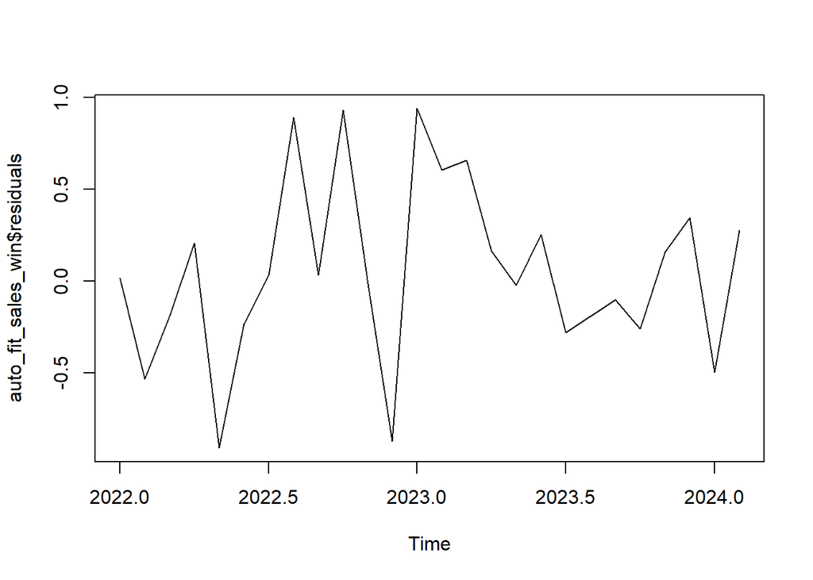

```r
plot(auto_fit_sales_win$residuals)
```

-In the ARIMA residual plot, we can observe that is random.

#Do a Histogram plot of residuals. What does the plot indicate?

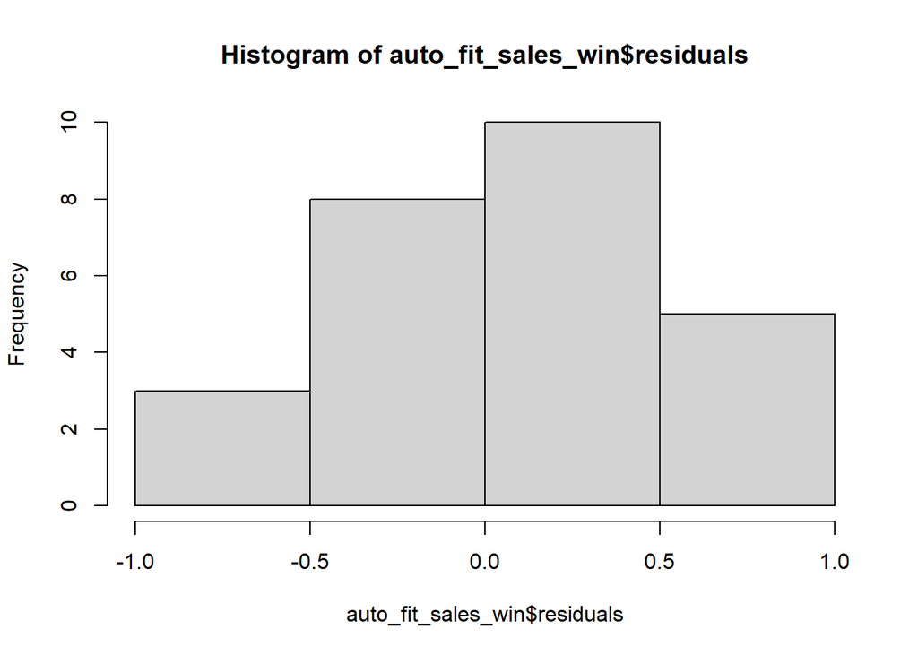

```r
hist(auto_fit_sales_win$residuals)
```

-After plotting the residuals of ARIMA, the histogram it is normally distributed, most of the values have a mean of zero.

#Do a plot of fitted values vs. residuals. What does the plot indicate?

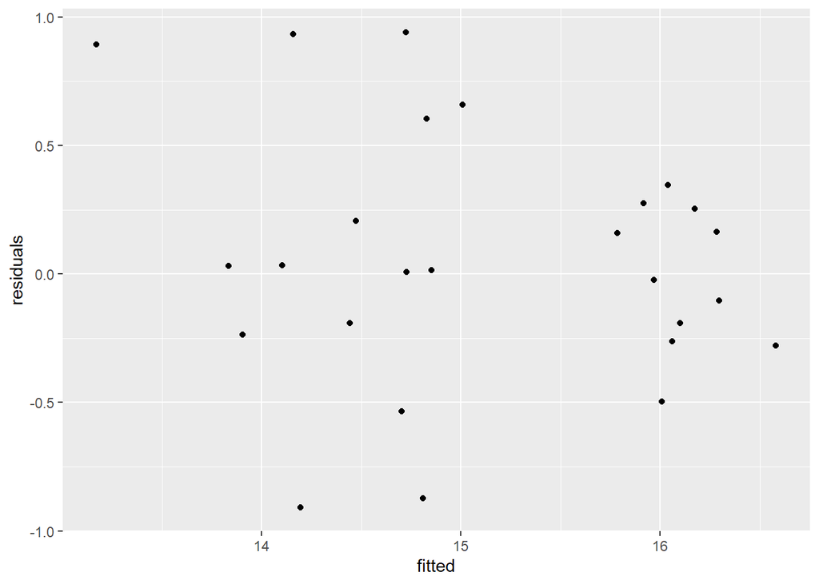

```r
plot_SARIMA = data.frame(fitted=auto_fit_sales_win$fitted, residuals=auto_fit_sales_win$residuals, actual=sales_win)
ggplot(plot_SARIMA, aes(x=fitted, y=residuals))+geom_point()
```

-Ideally the scatter plot between the fitted and residuals should not have any pattern. The fitted values should have zero effect on the residual values. However this plot shows that the fitted values have effect on the residual values.

#Do a plot of actual values vs. residuals. What does the plot indicate

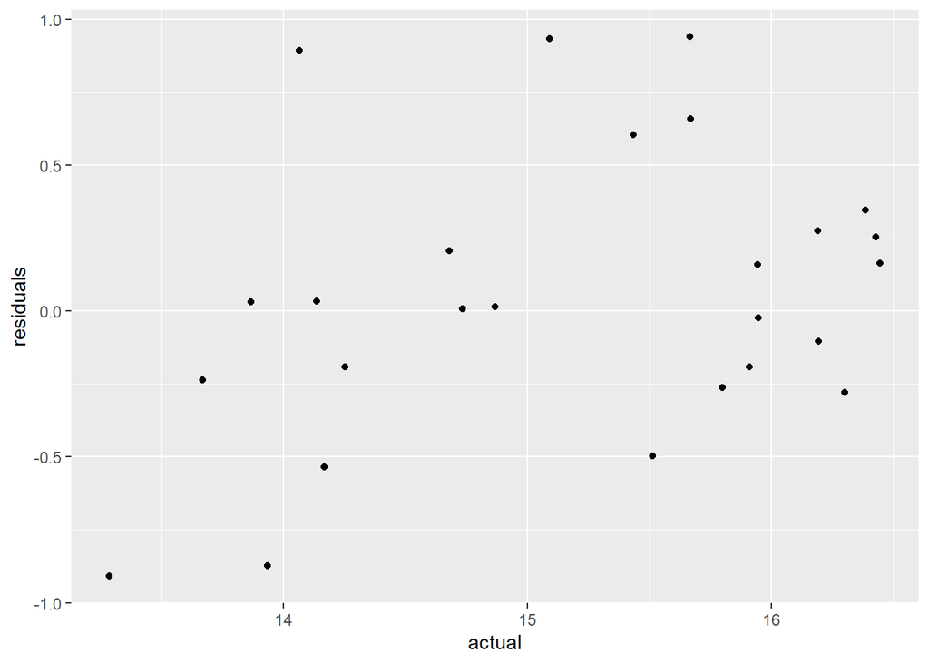

```r
ggplot(plot_SARIMA, aes(x=actual, y=residuals))+geom_point()
```

-Similar to the previous plot, it shows that the actual values have effect on the residual values. Ideally the scatter plot should not have any pattern.

#Do an ACF plot of the residuals? What does this plot indicate?

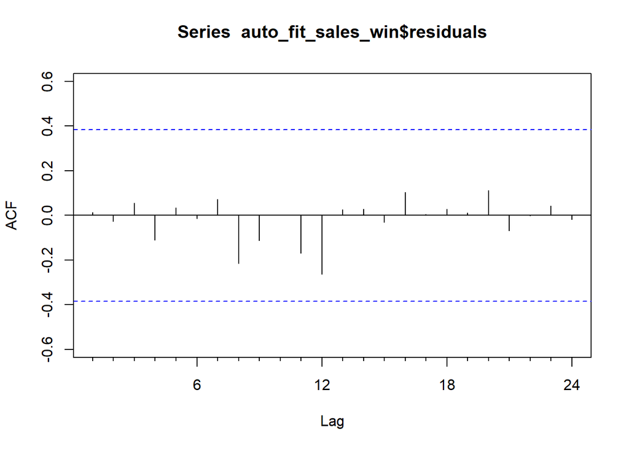

```r
Acf(auto_fit_sales_win$residuals)
```

-We can observe that all the values in the Acf plot of the SARIMA have not cross the confidence interval. Meaning that it has capture all the data.

#Print the 5 measures of accuracy for this forecasting technique.

```r
sarima_accuracy = accuracy(auto_fit_sales_win)
sarima_accuracy
```

```
##                      ME      RMSE      MAE       MPE     MAPE      MASE
## Training set 0.05453538 0.4850027 0.369875 0.2882758 2.481099 0.2323857
##                    ACF1
## Training set 0.01221806
```

#Forecast #Next one year. Show table and plot #Next two years. Show table and plot

```r
forecast_sarima = forecast(auto_fit_sales_win, 12)
forecast_sarima
```

```
##          Point Forecast    Lo 80    Hi 80    Lo 95    Hi 95
## Mar 2024       16.16459 15.48888 16.84029 15.13119 17.19799
## Apr 2024       15.74432 14.97511 16.51353 14.56792 16.92072
## May 2024       16.21102 15.33169 17.09035 14.86619 17.55584
## Jun 2024       16.03861 14.90985 17.16737 14.31233 17.76489
## Jul 2024       15.89209 14.67744 17.10673 14.03444 17.74973
## Aug 2024       16.16695 14.83107 17.50283 14.12390 18.21000
## Sep 2024       15.99026 14.50401 17.47652 13.71723 18.26329
## Oct 2024       15.97873 14.41346 17.54400 13.58486 18.37260
## Nov 2024       16.11564 14.44085 17.79042 13.55428 18.67700
## Dec 2024       15.98376 14.20283 17.76470 13.26006 18.70747
## Jan 2025       16.02266 14.16621 17.87911 13.18346 18.86186
## Feb 2025       16.07582 14.12419 18.02745 13.09106 19.06058
```

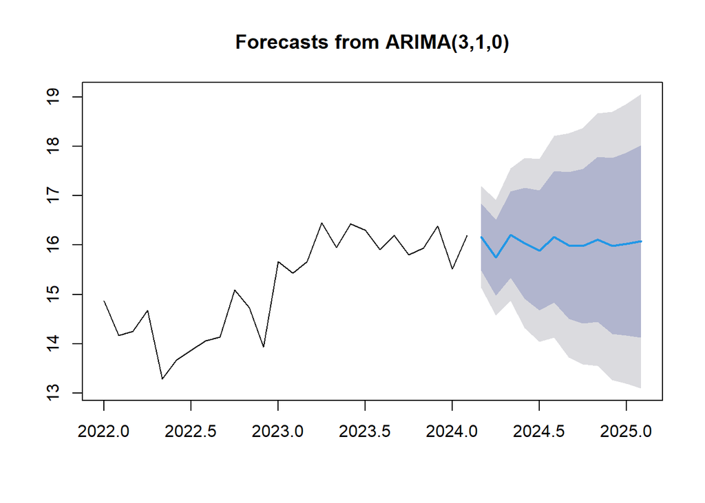

```r
plot(forecast_sarima)
```

```r
forecast_sarima2 = forecast(auto_fit_sales_win, 24)
forecast_sarima2
```

```
##          Point Forecast    Lo 80    Hi 80    Lo 95    Hi 95
## Mar 2024       16.16459 15.48888 16.84029 15.13119 17.19799
## Apr 2024       15.74432 14.97511 16.51353 14.56792 16.92072
## May 2024       16.21102 15.33169 17.09035 14.86619 17.55584
## Jun 2024       16.03861 14.90985 17.16737 14.31233 17.76489
## Jul 2024       15.89209 14.67744 17.10673 14.03444 17.74973
## Aug 2024       16.16695 14.83107 17.50283 14.12390 18.21000
## Sep 2024       15.99026 14.50401 17.47652 13.71723 18.26329
## Oct 2024       15.97873 14.41346 17.54400 13.58486 18.37260
## Nov 2024       16.11564 14.44085 17.79042 13.55428 18.67700
## Dec 2024       15.98376 14.20283 17.76470 13.26006 18.70747
## Jan 2025       16.02266 14.16621 17.87911 13.18346 18.86186
## Feb 2025       16.07582 14.12419 18.02745 13.09106 19.06058
## Mar 2025       15.99398 13.95788 18.03009 12.88003 19.10794
## Apr 2025       16.04045 13.93186 18.14903 12.81564 19.26525
## May 2025       16.05050 13.85911 18.24190 12.69906 19.40195
## Jun 2025       16.00746 13.74321 18.27172 12.54458 19.47035
## Jul 2025       16.04450 13.71125 18.37775 12.47610 19.61291
## Aug 2025       16.03687 13.63043 18.44331 12.35653 19.71720
## Sep 2025       16.01860 13.54621 18.49099 12.23740 19.79979
## Oct 2025       16.04270 13.50515 18.58026 12.16185 19.92356
## Nov 2025       16.03087 13.42733 18.63441 12.04909 20.01264
## Dec 2025       16.02601 13.36119 18.69083 11.95052 20.10151
## Jan 2026       16.03933 13.31318 18.76548 11.87004 20.20862
## Feb 2026       16.02910 13.24234 18.81587 11.76711 20.29109
```

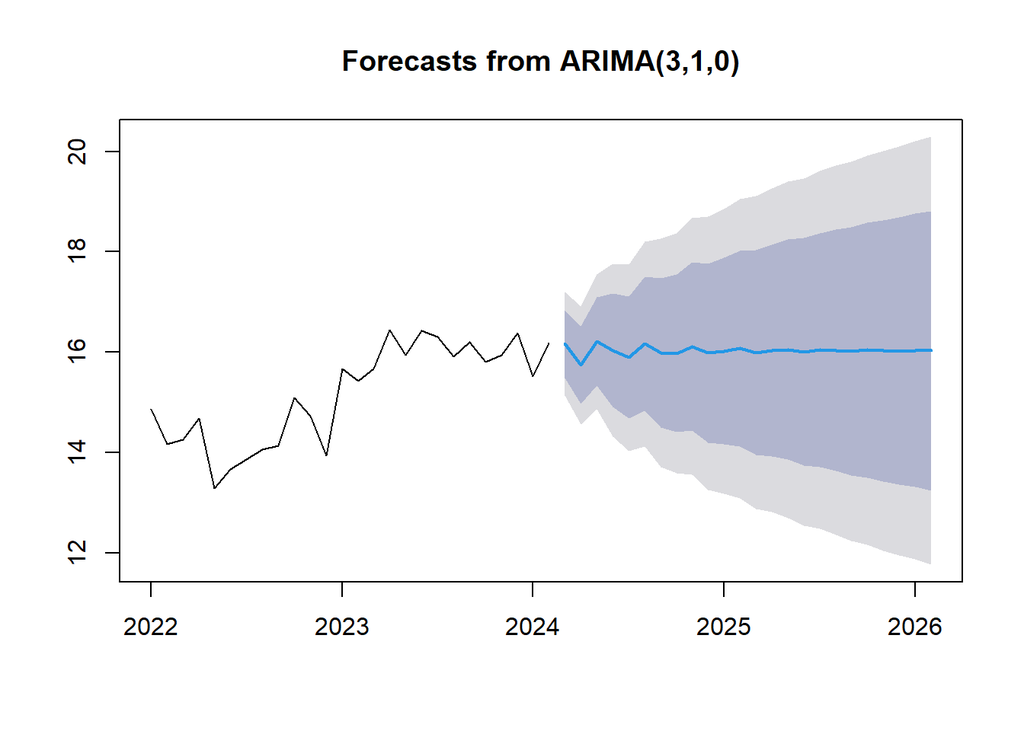

```r
plot(forecast_sarima2)
```

#Summarize this forecasting technique #How good is the accuracy?

–The model has an overall good accuracy with a low MAPE, MAE and MASE results.The MAPE has a good forecast error, indicating that only 2.48% of the predication are not accurate.

#What does it predict time series will be in one year and next two years?

```r
sarima_sales12 = forecast(auto_fit_sales_win, h=12)
sarima_sales12
```

```
##          Point Forecast    Lo 80    Hi 80    Lo 95    Hi 95
## Mar 2024       16.16459 15.48888 16.84029 15.13119 17.19799
## Apr 2024       15.74432 14.97511 16.51353 14.56792 16.92072
## May 2024       16.21102 15.33169 17.09035 14.86619 17.55584
## Jun 2024       16.03861 14.90985 17.16737 14.31233 17.76489
## Jul 2024       15.89209 14.67744 17.10673 14.03444 17.74973
## Aug 2024       16.16695 14.83107 17.50283 14.12390 18.21000
## Sep 2024       15.99026 14.50401 17.47652 13.71723 18.26329
## Oct 2024       15.97873 14.41346 17.54400 13.58486 18.37260
## Nov 2024       16.11564 14.44085 17.79042 13.55428 18.67700
## Dec 2024       15.98376 14.20283 17.76470 13.26006 18.70747
## Jan 2025       16.02266 14.16621 17.87911 13.18346 18.86186
## Feb 2025       16.07582 14.12419 18.02745 13.09106 19.06058
```

```r
sarima_sales24 = forecast(auto_fit_sales_win, h=24)
sarima_sales24
```

```
##          Point Forecast    Lo 80    Hi 80    Lo 95    Hi 95
## Mar 2024       16.16459 15.48888 16.84029 15.13119 17.19799
## Apr 2024       15.74432 14.97511 16.51353 14.56792 16.92072
## May 2024       16.21102 15.33169 17.09035 14.86619 17.55584
## Jun 2024       16.03861 14.90985 17.16737 14.31233 17.76489
## Jul 2024       15.89209 14.67744 17.10673 14.03444 17.74973
## Aug 2024       16.16695 14.83107 17.50283 14.12390 18.21000
## Sep 2024       15.99026 14.50401 17.47652 13.71723 18.26329
## Oct 2024       15.97873 14.41346 17.54400 13.58486 18.37260
## Nov 2024       16.11564 14.44085 17.79042 13.55428 18.67700
## Dec 2024       15.98376 14.20283 17.76470 13.26006 18.70747
## Jan 2025       16.02266 14.16621 17.87911 13.18346 18.86186
## Feb 2025       16.07582 14.12419 18.02745 13.09106 19.06058
## Mar 2025       15.99398 13.95788 18.03009 12.88003 19.10794
## Apr 2025       16.04045 13.93186 18.14903 12.81564 19.26525
## May 2025       16.05050 13.85911 18.24190 12.69906 19.40195
## Jun 2025       16.00746 13.74321 18.27172 12.54458 19.47035
## Jul 2025       16.04450 13.71125 18.37775 12.47610 19.61291
## Aug 2025       16.03687 13.63043 18.44331 12.35653 19.71720
## Sep 2025       16.01860 13.54621 18.49099 12.23740 19.79979
## Oct 2025       16.04270 13.50515 18.58026 12.16185 19.92356
## Nov 2025       16.03087 13.42733 18.63441 12.04909 20.01264
## Dec 2025       16.02601 13.36119 18.69083 11.95052 20.10151
## Jan 2026       16.03933 13.31318 18.76548 11.87004 20.20862
## Feb 2026       16.02910 13.24234 18.81587 11.76711 20.29109
```

-I think the sales for the next and two years will remaining constant with some increases and decreases in sales in some months.

#Accuracy Summary #Show a table of all the forecast methods above with their accuracy measures.

```r
table_accuracy=data.frame(Method=c("Naive","Exponential Smoothing","Holt-Winters","SARIMA"), ME=c(naive_accuracy[1,"ME"],ses_accuracy[1,"ME"], hw_accuracy[1,"ME"],sarima_accuracy[1,"ME"]), RMSE=c(naive_accuracy[1,"RMSE"], ses_accuracy[1,"RMSE"], hw_accuracy[1,"RMSE"],sarima_accuracy[1,"RMSE"]), MAE=c(naive_accuracy[1,"MAE"], ses_accuracy[1,"MAE"], hw_accuracy[1,"MAE"],sarima_accuracy[1,"MAE"]), MAPE=c(naive_accuracy[1,"MAPE"], ses_accuracy[1,"MAPE"], hw_accuracy[1,"MAPE"],sarima_accuracy[1,"MAPE"]), MASE=c(naive_accuracy[1,"MASE"], ses_accuracy[1,"MASE"], hw_accuracy[1,"MASE"],sarima_accuracy[1,"MASE"]))
print(table_accuracy)
```

```
##                  Method          ME      RMSE       MAE     MAPE      MASE
## 1                 Naive  0.05300000 0.6498938 0.5141200 3.411387 0.3230122
## 2 Exponential Smoothing  0.10090076 0.5662150 0.4348547 2.889828 0.2732112
## 3          Holt-Winters -0.01760396 0.6555590 0.5118556 3.307403 0.3215895
## 4                SARIMA  0.05453538 0.4850027 0.3698750 2.481099 0.2323857
```

#Separately define each forecast method and why it is useful. Show the best and worst forecast method for each of the accuracy measures.

Naive: -The naive method will take the previous data to forecast the next value and assumes no trend, seasonality or any fluctuations.Naive is very simple to forecast and could be the baseline to compare to other methods. Exponential Smoothing: -The exponential smoothing calculates the next forecast value as a weighted average of the actual value. With the weighted average it give more weight to more recent data and ca be beneficial when the analysis has trend data. Holt-Winters: -The Holt-Winter method could be apply when the data has level, trend and seasonality. Also, holt-winters can be use for additive and multiplicative forecasts.

#Conclusion #Summarize your analysis of time series value over the time period.

-After performing the forecast above, we can conclude SARIMA performs better than the other methods. -SARIMA has the lowest accuracy results.

#Based on your analysis and forecast above, do you think the value of the time series will increase, decrease, or stay flat over the next year? How about the next 2 years?

-I think the sales for the next and two years will remaining constant with some increases and decreases in sales in some months.

#Rank forecasting methods for this time series based on historical values.

```r
results=data.frame(Method=c("Naive","Exponential Smoothing","Holt-Winters","SARIMA"), ME=c(naive_accuracy[1,"ME"],ses_accuracy[1,"ME"],hw_accuracy[1,"ME"],sarima_accuracy[1,"ME"]), RMSE=c(naive_accuracy[1,"RMSE"], ses_accuracy[1,"RMSE"], hw_accuracy[1,"RMSE"],sarima_accuracy[1,"RMSE"]), MAE=c(naive_accuracy[1,"MAE"], ses_accuracy[1,"MAE"],hw_accuracy[1,"MAE"],sarima_accuracy[1,"MAE"]), MAPE=c(naive_accuracy[1,"MAPE"], ses_accuracy[1,"MAPE"],hw_accuracy[1,"MAPE"],sarima_accuracy[1,"MAPE"]), MASE=c(naive_accuracy[1,"MASE"], ses_accuracy[1,"MASE"],hw_accuracy[1,"MASE"],sarima_accuracy[1,"MASE"]))

results$rank_ME = rank(results$ME)
results$rank_RMSE = rank(results$RMSE)
results$rank_MAE = rank(results$MAE)
results$rank_MAPE = rank(results$MAPE)
results$rank_MASE = rank(results$MASE)
print(results)
```

```
##                  Method          ME      RMSE       MAE     MAPE      MASE
## 1                 Naive  0.05300000 0.6498938 0.5141200 3.411387 0.3230122
## 2 Exponential Smoothing  0.10090076 0.5662150 0.4348547 2.889828 0.2732112
## 3          Holt-Winters -0.01760396 0.6555590 0.5118556 3.307403 0.3215895
## 4                SARIMA  0.05453538 0.4850027 0.3698750 2.481099 0.2323857
##   rank_ME rank_RMSE rank_MAE rank_MAPE rank_MASE
## 1       2         3        4         4         4
## 2       4         2        2         2         2
## 3       1         4        3         3         3
## 4       3         1        1         1         1
```